Kompetensförsörjning  
i Dalarna

# Kompetensförsörjning i Dalarna

Rapporten är skapad av Samhällsanalys, Region Dalarna  
Senast uppdaterad: 2026-04-23

# Sammanfattning

**Mer om rapportformatet**

Webbrapportformatet ger möjligheter att enkelt automatisera uppdateringar när ny statistik finns tillgänglig. Publiceringsdatum visas längst upp på sidan.

För att förstora diagrammen i rapporten, högerklicka på ett diagram och välj alternativet “Öppna bild i ny flik”.

Genom att klicka på blå text går det att följa länkarna som öppnas i en ny flik.

# Inledning

Sverige och Dalarna har en åldrande befolkning och aktuella prognoser från SCB ([SCB, 2024](https://www.scb.se/contentassets/3c424ebe4366403da0d30dfba52fba87/uf0515_2023a01_br_am85br2401.pdf/)) pekar på en utveckling där allt färre i arbetsför ålder ska försörja allt fler unga och gamla. Den demografiska försörjningskvoten mäter förhållandet mellan individer i arbetsför ålder, och unga och gamla. Mellan 2006 och 2024 har försörjningskvoten i Dalarna ökat från ungefär 76 till 92.1. Det innebär att 100 personer i arbetsför ålder ska försörja ungefär 92 personer utanför arbetsför ålder. Redan idag är försörjningskvoten i Dalarna den högsta i landet och förväntas öka över tid. Det kommer att förstärka den brist på arbetskraft som råder redan i dag och påverka näringslivets och offentlig sektors möjlighet att rekrytera personal.

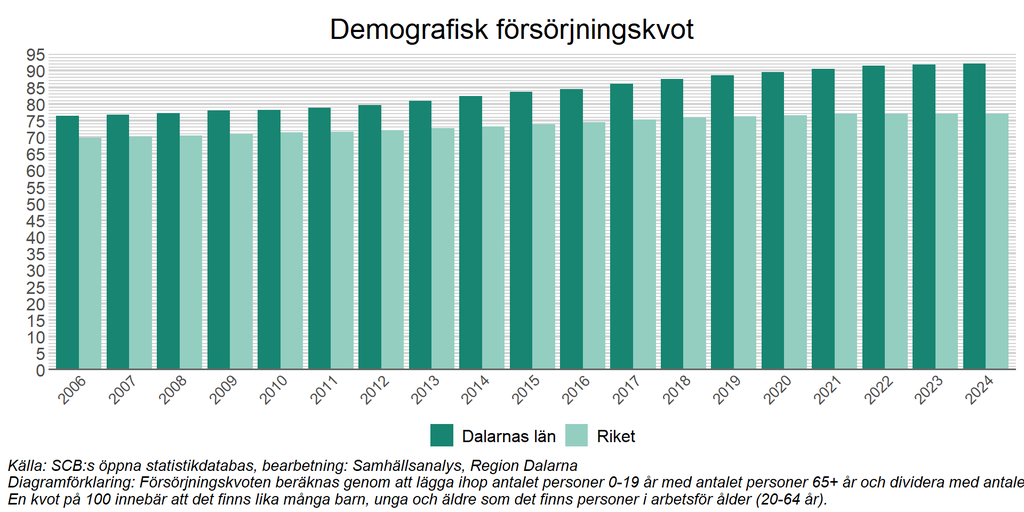

Figur 1.

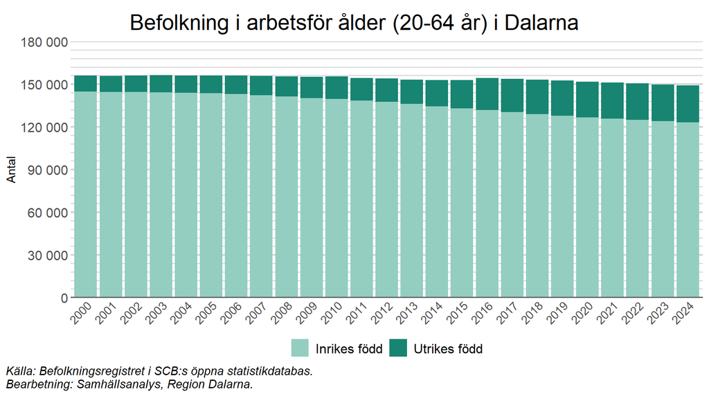

Figur 2.

Befolkningsutvecklingen i Dalarna har varierat över tid med såväl uppgångar som nedgångar. Den senaste stora nedgången var i samband med den ekonomiska krisen runt millennieskiftet och en uppgång skedde i samband med flyktingkrisen 2016. Såväl 2023 som 2025 observerades tydliga nedgångar i Dalarnas befolkning. För en mer ingående analys av befolkningsutvecklingen, se [Befolkningsutvecklingen i Dalarna](https://samhallsanalys.regiondalarna.se/befolkningsutveckling).

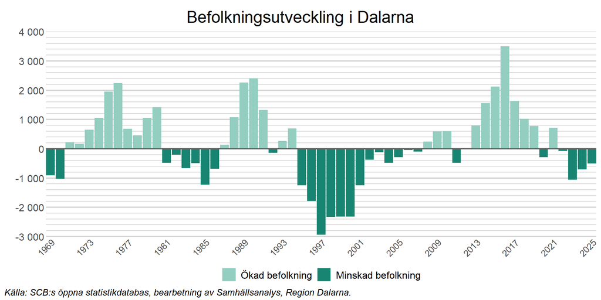

Figur 3.

En utveckling mot en allt äldre befolkning leder till arbetskraftsbrist, vilket är en trend som kan observeras på många håll i landet. Därutöver kan även kompetensbrist uppstå, om de som står till arbetsmarknadens förfogande inte har de kompetenser som efterfrågas ([Tillväxtanalys, 2024](https://www.tillvaxtanalys.se/publikationer/rapport/rapportserien/arbetskraftsochkompetensbrist.126683.html)).

Att hitta lösningar på kompetensförsörjningsutmaningen blir avgörande för att skapa en hållbar regional utveckling. Den regionala utvecklingsstrategin, [Dalastrategin 2030](https://www.regiondalarna.se/globalassets/regional-utveckling/dalastrategin-2030-tillsammans-for-ett-hallbart-dalarna-dec.pdf/), pekar även ut en väl fungerande kompetensförsörjning som ett område där nya lösningar måste hittas i perspektivet av en åldrande befolkning.

Snabb teknologisk utveckling skapar behov av förändrade kompetenser samtidigt som utbildningsområdet är mer trögrörligt. Det leder till att jämvikt mellan efterfrågan och utbud, och matchning på arbetsmarknaden, blir svårare att uppnå med försämrad effektivitet som följd. Frågan om arbetskrafts- och kompetensbrist är komplex.

Rapporten syftar till att belysa läget kring kompetensförsörjningen i länet och fungera som en grund för informerade beslut och samverkan. Målet är att peka på ett antal utmaningar som arbetsmarknadens aktörer behöver adressera för att uppnå Dalastrategins målbild för 2030 om en väl fungerande kompetensförsörjning.

Region Dalarnas ambition är att utveckla rapportens innehåll och omfång i kommande utgåvor genom fördjupningar av olika avsnitt, som ytterligare kan bidra till kunskap om arbetsmarknaden. Som exempel kan nämnas att inkludera mer prognosunderlag för arbetsmarknaden som helhet och för olika branscher.

Rapporten redovisar först efterfrågan respektive utbud på arbetskraft i Dalarna. Därefter studeras de olika utbildningsnivåerna i Dalarna mer ingående, följt av en genomgång av hur väl arbetsmarknaden i Dalarna fungerar. Rapporten avslutas med en sammanfattande diskussion.

# 1 Efterfrågan på arbetskraft

[Reglab (2014)](https://tillvaxtverket.se/download/18.27a54dd21870d50fcb36cd6/1679644966939/Regionala-Matchningsindikatorer-%E2%88%92-dec-2014.pdf) definerar arbetskraftsefterfrågan som *“mängden arbetskraft och dess egenskaper - kompetens, kunskaper, utbildning, yrkeserfarenheter - som arbetsgivare efterfrågar och/eller behöver, i nuläget eller längre fram”*.

Efterfrågan på arbetskraft är inte är helt enkelt att mäta. I teorin kan den härledas från efterfrågan på varor och tjänster, men är även beroende av andra faktorer som påverkar produktionsförhållanden på olika marknader.

I denna rapport får de regionala matchningsindikatorer som togs fram av Reglab 2014 utgöra grunden för innehållet för såväl efterfrågan som utbud. Primärt mäts då efterfrågan i form av lediga jobb och inflödet av jobb.

## 1.1 Lediga jobb

Över tid har antalet lediga jobb i länet ökat successivt sedan den lägsta noteringen i efterdyningarna av finanskrisen 2008. Privat sektor står för den högsta andelen av efterfrågan, med undantag för några enstaka observationstillfällen.

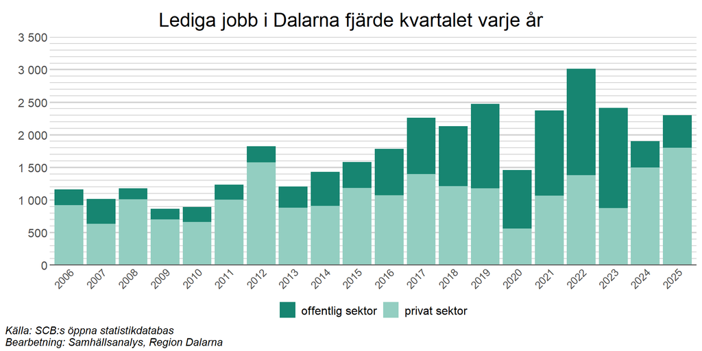

Figur 4.

## 1.2 Jobbinflöden

Efter nedgången på arbetsmarknaden i samband med finanskrisen 2008, då omsättningen på arbetsmarknaden i termer av jobbinflöde låg på drygt 14 procent, har utvecklingen varit i stort sett positiv fram till pandemin 2020. Då skedde en kraftig, men också tillfällig nedgång. 2022-2023 var jobbinfödet 18 procent, vilket var något sämre än perioden innan.

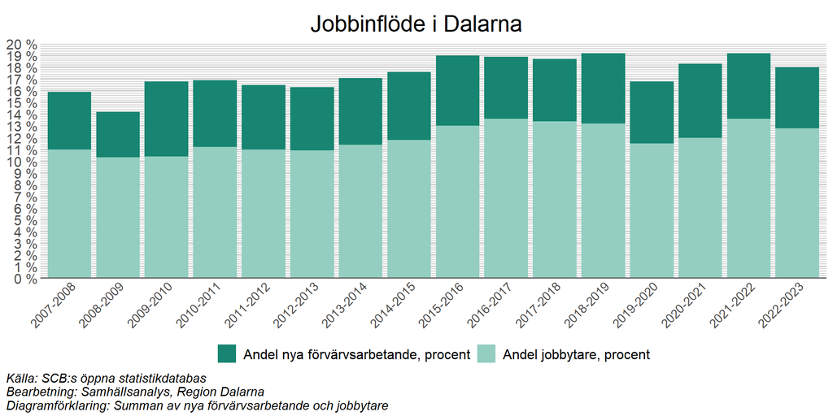

Figur 5.

En observation är att majoriteten av utlysta tjänster tillsätts av individer som redan är aktiva i yrkeslivet, inte de som är nyinträdda på arbetsmarknaden. De nyinträdda ligger runt 5-6 procent, medan andelen jobbytare är ungefär det dubbla.

## 1.3 Kompetenskrav

**Mer information om statistiken**

För att beskriva kompetens- och kvalifikationskrav har denna rapport utgått ifrån yrkesregistret i SCB:s öppna statistikdatabas. I detta register delas yrken in i nio olika grupper. Utifrån dessa grupper klassificeras de kategorier som syns i diagrammen nedan. Chefsyrken och yrken som kräver olika typer av högskolekompetens har samma benämning i klassificeringen som i SCB:s kategorisering. Yrken med krav på kortare utbildning eller introduktion har klassificerats som enklare yrken. Övriga yrken klassificeras som motsvarande gymnasial kompetens. Läs mer på [SCB:s hemsida](https://www.scb.se/dokumentation/klassifikationer-och-standarder/standard-for-svensk-yrkesklassificering-ssyk/).

Hur stor andel som jobbar inom yrken med olika former av kvalifikationskrav speglar olika arbetsgivares efterfrågan på kompetens. Sammansättningen av kvalifikationskrav varierar relativt mycket mellan Sveriges län. Gotland har störst andel som arbetar inom enklare yrken, med ungefär 7 procent av de förvärvsarbetande i länet. Dock jobbar generellt relativt få inom dessa yrken, oavsett region.

Om vi i stället fokuserar på yrken med kvalifikationskrav som motsvarar gymnasial kompetens är skillnaderna större mellan Sveriges län. Lägst andel återfinns i Stockholm där ungefär 37 procent av de förvärvsarbetande har den typen av yrken, medan störst andel återfinns i Kalmar med ungefär 57 procent av de förvärvsarbetande.

För yrken med högre kvalifikationskrav, exempelvis “motsvarande fördjupad högskolekompetens”, är situationen mer eller mindre det omvända. Högst andel har Stockholm med ungefär 32 procent av de förvärvsarbetande, medan Kalmar med ungefär 20 procent har lägst andel. Kvalifikationskraven i Dalarna påminner om de i Kalmar, med relativt stor andel av de förvärvsarbetande inom yrken med motsvarande gymnasial kompetens och färre inom yrken som kräver olika former av högskolekompetens.

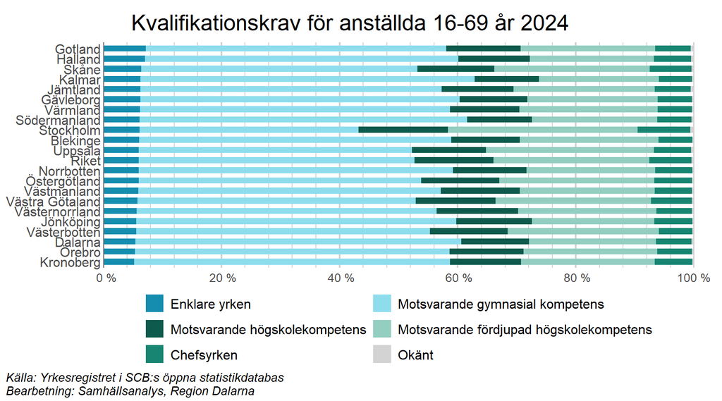

Figur 6.

Även mellan branscher varierar kvalifikationskraven. Högst andel som arbetar inom yrken av enklare karaktär återfinns i Dalarna inom hotell och restaurang, där ungefär 44 procent jobbar inom den typen av yrke. Detta kan delvis förklaras av att hotell och restaurang också är den bransch i Dalarna med högst andel utrikes födda anställda. Personer som tillhör denna grupp tenderar även att ha förgymnasiala utbildningar i större utsträckning än inrikes födda.

Även inom företagstjänster är många yrken av enklare karaktär, medan det omvända gäller inom exempelvis utbildning, offentlig förvaltning samt IT och kommunikation. Där arbetar omkring hälften av de anställda inom yrken som med kvalifikationskrav motsvarande fördjupad högskolekompetens.

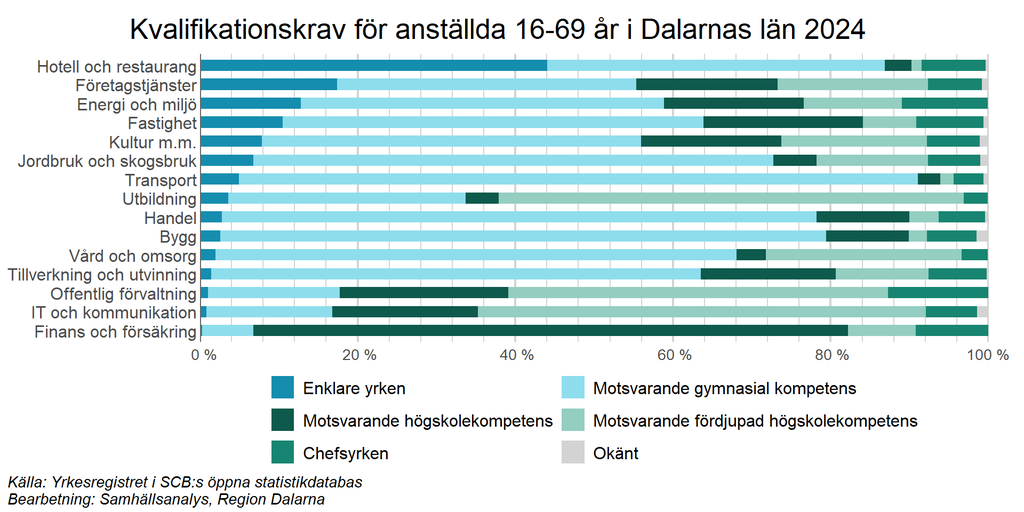

Figur 7.

## 1.4 Åldersstruktur

Hotell och restaurang är den bransch där den klart största andelen yngre arbetar, 19 procent av de förvärvsarbetande är mellan 16 och 19 år gamla. Även inom kultur, fritid och nöje är många av de förvärvsarbetande unga, vilket är ett kvitto på att många unga tar sitt första steg in på arbetsmarknaden inom dessa branscher.

Det omvända gäller för jord- och skogsbruk där cirka 52 procent av de förvärvsarbetande är äldre än 60 år. Detta kan delvis förklaras med att alla som äger en skogsfastighet räknas som förvärvsarbetande och många av dessa tenderar att vara äldre.

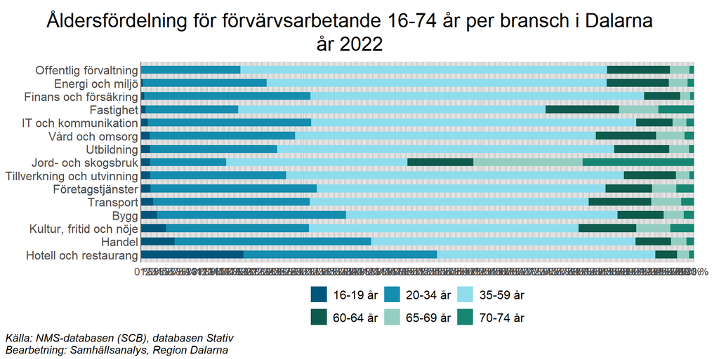

Figur 8.

Störst antal personer över 60 år arbetar i Dalarna inom vård och omsorg. Ungefär 4 700 förvärvsarbetande inom branschen är minst 60 år och kommer således att gå i pension inom 5-10 år. Detta, i kombination med en befolkning som blir allt äldre och därför efterfrågar mer vård, leder till ett stort rekryteringsbehov inom vård och omsorg idag och i framtiden.

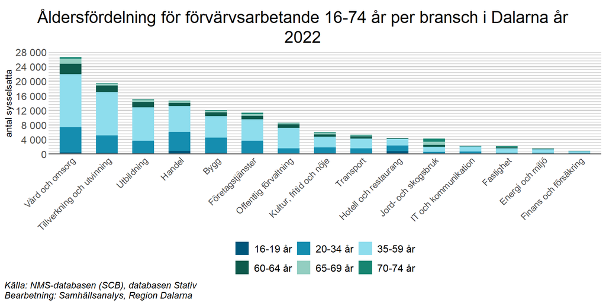

Figur 9.

# 2 Utbud av arbetskraft

Företagens möjlighet att kompetensförsörja sina verksamheter utgår från det kortsiktiga utbudet av arbetskraft och de individer som står till arbetsmarknadens förfogande, det vill säga de som arbetar och de som söker arbete. Utbudet av arbetskraft i ett visst område består av de som bor i området, de som kan pendla till området och de som kan distansarbeta. Omfattningen på utbudet påverkas även av antal timmar de önskar arbeta.

Det långsiktiga utbudet av arbetskraft påverkas av förändringar i individers utbildningsnivåer, kompetensutveckling, in- och utflyttning, pendlingsbenägenhet med mera. Att beskriva utvecklingen inom dessa områden är viktigt för att kunna bedöma hur kompetensförsörjningen kommer att se ut på längre sikt. Det är även viktigt att studera de som idag inte ingår i arbetskraften, men som kan göra det i framtiden.

I detta avsnitt kommer utbudet av arbetskraft beskrivas utifrån hur stor andel av befolkningen som är i vad som brukar kallas för arbetsför ålder, det vill säga mellan 20 och 64 år gamla. Visserligen jobbar människor allt längre upp i åldrarna, men den största andelen arbetar när de är i arbetsför ålder.

Historisk data över exempelvis antal förvärvsarbetande i olika branscher visar när efterfrågan möter utbud, det vill säga när en person blir anställd. Efterfrågan kan dock överstiga utbudet. Det blir exempelvis allt vanligare att företag har svårt att hitta arbetskraft, något som inte återspeglas i figurerna nedan.

## 2.1 Arbetskraftsdeltagande

Personer som ingår i arbetskraften är antingen förvärvsarbetande eller inskrivna på arbetsförmedlingen. Sedan 2006 har arbetskraftsdeltagandet, för både kvinnor och män i arbetsför ålder, ökat. För män är andelen ungefär 89 procent under 2023 medan kvinnors andel var omkring 86 procent vid samma tidpunkt. Över tid har dock skillnaden mellan män och kvinnors arbetskraftsdeltagande minskat.

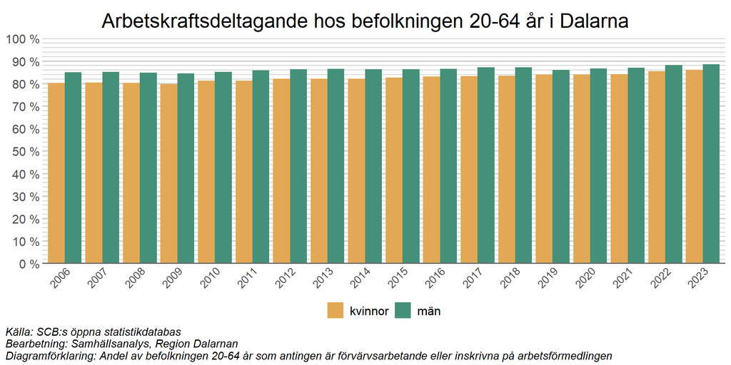

Figur 10.

Arbetskraftsdeltagandet i Dalarna under 2023 är högre än riksgenomsnittet för såväl män som kvinnor.

## 2.2 Förvärvsarbetande

**Mer information om statistiken**

Förvärvsarbetande omfattar både anställda och företagare. Har personen fått en lön i november som överstiger 99 kronor klassificeras personen som förvärvsarbetande. För egenföretagare gäller, liksom tidigare, att de personer som under referensåret har deklarerat för aktiv näringsverksamhet klassificeras som förvärvsarbetande.

I Dalarna är den klart största branschen, sett till antalet förvärvsarbetande, vård och omsorg med ungefär 28 000 anställda. Detta kan delvis förklaras med att befolkningen i Dalarna, precis som många andra glesbefolkade län, har en relativt hög medelålder, något som medför att mer vård och omsorg efterfrågas. SCB bedömer att behovet av arbetskraft inom vård och omsorg kommer att öka i takt med en åldrande befolkning, särskilt inom äldreomsorgen ([SCB, 2024](https://www.scb.se/contentassets/3c424ebe4366403da0d30dfba52fba87/uf0515_2023a01_br_am85br2401.pdf/)).

Andra branscher med många anställda i Dalarna är tillverkning och utvinning samt utbildning, med cirka 20 000 respektive 14 000 anställda. Inom vård och omsorg samt utbildning är en övervägande majoritet av de sysselsatta kvinnor, medan det omvända gäller för tillverkning och utvinning, bygg samt transport.

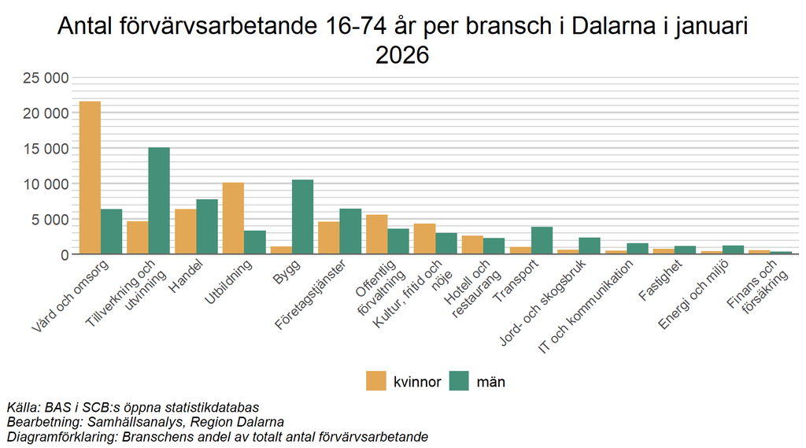

Figur 11.

Historiskt har tillverkning och utvinning varit den största branschen i Dalarna sett till antalet anställda, men vård och omsorg är idag störst. Att tillverkning och utvinning minskat i antal anställda sedan 1990 är en förändring som återspeglar den allmänna trenden i många regioner där tjänstesektorn har fått ökad betydelse över tid. Dessutom har företag inom tillverkning och utvinning idag en mer automatiserad produktion än de hade för 30 år sedan, vilket medför att det behövs färre antal anställda i produktionen.

Notera även att branschgrupperingarna i diagrammet nedan skiljer sig något från de i det föregående diagrammet. Exempelvis är branscherna handel och transport sammanslagna baserat på branschgrupperingen 1990.

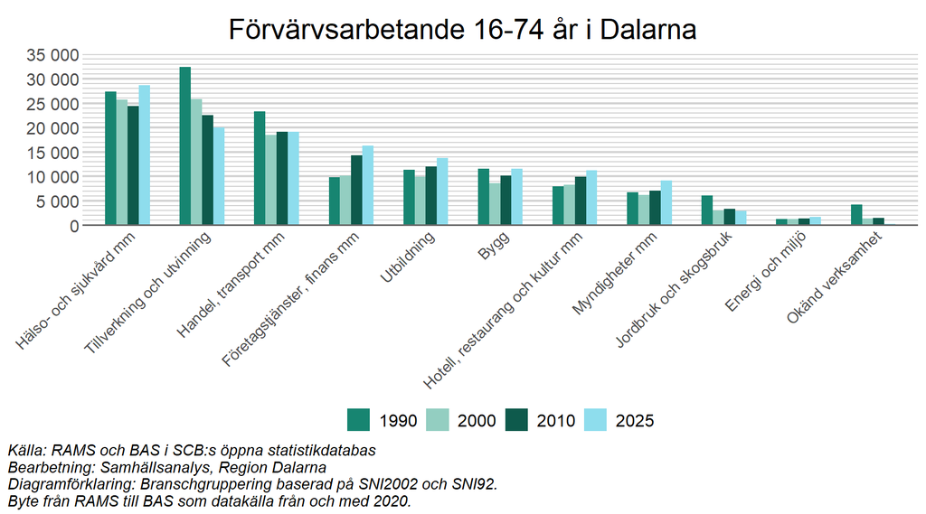

Figur 12.

Bland övriga branscher har det skett en stor ökning av antalet förvärvsarbetande inom företagstjänster och finans där det jobbar ungefär 66 procent fler idag än 1990. Även inom kultur och utbildning jobbar många fler idag än 1990. Ökningen inom företagstjänster beror sannolikt på att många företag idag upphandlar vissa tjänster, såsom rekrytering, lönehantering, lokalvård med mera. Om exempelvis ett tillverkande företag som SSAB tidigare anställde lokalvårdare själva, så återfanns dessa inom branschen tillverkning och utvinning, men om företaget istället upphandlar sådan verksamhet till andra företag specialiserade inom området, räknas lokalvårdarna i stället som förvärvsarbetande inom branschen företagstjänster, finans mm.

Dessa sektorer har således bidragit till att bredda och diversifiera arbetsmarknaden i Dalarna. Sammantaget speglar denna utveckling en omställning mot en mer serviceorienterad ekonomi, medan vissa traditionella sektorer har minskat i omfattning.

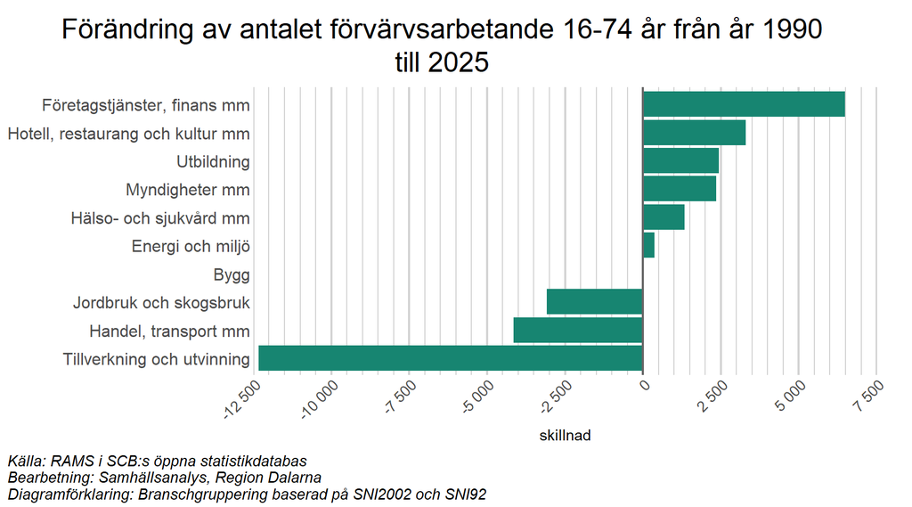

Figur 13.

Olika kommuner i Dalarna har olika branschstrukturer, vilket åskådliggörs i figuren nedan. I södra delarna av länet, exempelvis Avesta och Ludvika, är tillverkningsindustrin fortfarande en av de största arbetsgivarna, med företag såsom Outokumpu (Avesta) och Hitachi (Ludvika). I de kommuner som har ett akutsjukhus, Falun och Mora, är vård och omsorg den viktigaste branschen, vilket även gäller för Säter och Rättvik. I Leksand spelar handel en stor roll, då kommunen är säte för bland annat Clas Ohlson.

I de nordligaste kommunerna (Malung-Sälen, Orsa och Älvdalen) är byggindustrin en av de största arbetsgivarna, vilket delvis kan förklaras av den byggboom som skett i Dalarnas fjällvärld. Det är även tydligt att näringslivet i länets två största orter (Borlänge och Falun) domineras av tjänstesektorn (handel, företagstjänster, och offentlig förvaltning) samt utbildning.

[figure not shown]

Figur 14.

## 2.3 Befolkning i arbetsför ålder

**Mer information om statistiken**

Inrikes flyttnetto är antalet som flyttar till en region från andra regioner i Sverige minus antalet som flyttar från en region till andra regioner i Sverige. Utrikes flyttnetto är invandring till en region minus utvandring/emigrering från en region. Demografisk förändring är den del av befolkningsförändringen som inte kan förklaras av inrikes och utrikes flyttnetto.

Bland Sveriges regioner är de befolkningsmässigt största även de vars befolkning i arbetsför ålder (20 - 64 år) har ökat mest det senaste dryga decenniet. Typiskt för dessa regioner är att de har ett positivt inrikes flyttnetto, det vill säga människor i arbetsför ålder flyttar från andra delar av Sverige till exempelvis Stockholm eller Uppsala i större utsträckning än de flyttar därifrån. För många mindre regioner, såsom Dalarna, gäller det omvända. Härifrån flyttar många till andra regioner i Sverige, såväl utrikes födda som exempelvis har hamnat i Dalarna när de invandrat till Sverige, som inrikes födda.

I Sverige har invandringen (utrikes flyttnetto) haft en positiv inverkan på den arbetsföra delen av befolkningens storlek det senaste dryga decenniet. Samtliga regioner har ett positivt utrikes flyttnetto.

I vissa regioner, däribland Dalarna, motverkas dock denna ökning av ett negativt inrikes flyttnetto och en negativ demografisk förändring, vilket sammantaget ger en minskande befolkning.

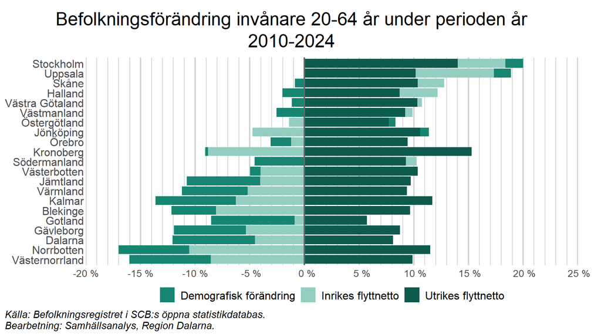

Figur 15.

Om den arbetsföra befolkningen delas upp i inrikes respektive utrikes födda, framträder en mer nyanserad bild än den i föregående diagram. Tydligt är att Dalarnas arbetsföra befolkning minskat i antal de senaste decennierna och att detta drivs av att den inrikes födda delen av befolkningen minskar. I Dalarna har antalet inrikes födda invånare i arbetsför ålder minskat från ungefär 145 000 personer år 2000 till cirka 123 000 år 2024. Samtidigt har en relativt stor invandring medfört att utrikes födda invånare i arbetsför ålder har ökat från ungefär 11 000 personer år 2000 till cirka 26 000 år 2024.

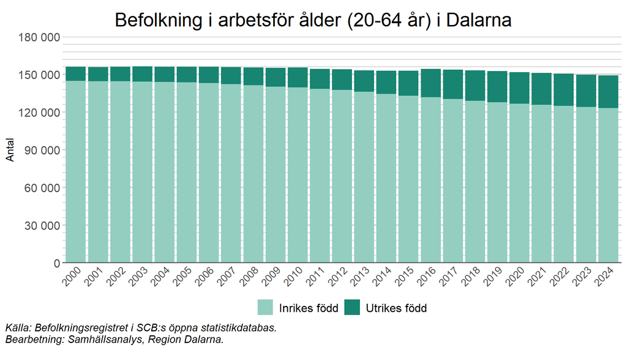

Figur 16.

I figuren nedan blir det tydligt att de unga (0-19 år) och de i arbetsför ålder (20-64 år) har minskat sedan slutet på 1960-talet, medan de äldre (65-79 år och 80+ år) har ökat kraftigt under samma tidsperiod, en utveckling som dessutom prognostiseras fortsätta i framtiden för de allra äldsta (80+ år).

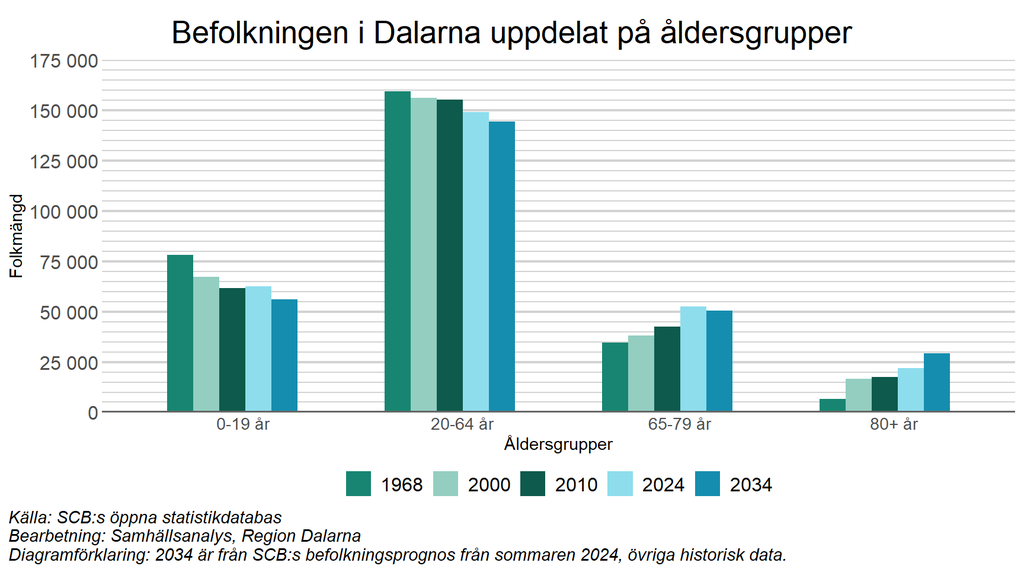

Figur 17.

## 2.4 Pendlare

**Mer information om statistiken**

Andel inpendlare beräknas genom att dela antal inpendlare (personer som förvärvsarbetar i kommunen/regionen och bor i en annan kommun/region) med antal förvärvsarbetande som arbetar i kommunen/regionen (dagbefolkning). Andel utpendlare beräknas genom att dela antal utpendlare (personer som bor i kommunen/regionen och förvärvsarbetar i en annan kommun/region) med antal förvärvsarbetande som bor i kommunen/regionen (nattbefolkning).

Personer som pendlar till arbete är en komponent av arbetskraften som behöver studeras. Om arbetsmarknaden i den egna kommunen är svag, kan pendling till andra kommuners arbetsmarknader erbjuda möjligheter till arbete och bidra till en totalt sett starkare arbetsmarknad.

För att fördjupa förståelsen för utbudet av arbetskraft bör lokala arbetsmarknadsregioner inkluderas i analysen, utöver kommuner eller län som analysenhet. Lokala arbetsmarknadsregioner skapas utifrån pendlingsrelationer mellan kommuner.

Det som i första hand påverkar pendlingsmönster är närheten till större städer. Högst andel utpendlare i Sverige har Uppsala län, där drygt var fjärde boende som förvärvsarbetar gör det i ett annat län, Stockholm i stor utsträckning. Även Södermanland och Västmanland, som båda ligger relativt nära Stockholm, har stor utpendling. Hallands närhet till arbetsmarknaden i Göteborg med omnejd bidrar sannolikt till en utpendlingsandel på cirka 23 procent. Störst andel inpendlare har Uppsala län. I Dalarna är andelen förvärvsarbetande som pendlar över länsgräns relativt liten.

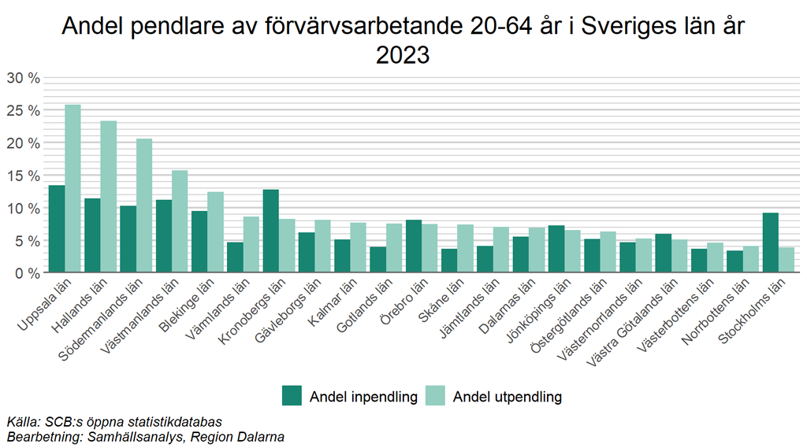

Figur 18.

Att flera av kommunerna i Dalarna tillhör större arbetsmarknadsregioner blir tydligt i diagrammet nedan. Störst andel utpendling har Säter där knappt tre av fem av de boende som förvärvsarbetar gör det i en annan kommun, i stor utsträckning Borlänge. Även Gagnef (pendling till Borlänge), Smedjebacken (pendling till Ludvika) och Orsa (pendling till Mora) är kommuner där många arbetspendlar till andra kommuner. Störst inpendling har Borlänge, där 37 procent av de förvärvsarbetande bor i en annan kommun. I norra Dalarna, med flera kommuner som till ytan är stora, exempelvis Malung-Sälen och Älvdalen, är situationen det omvända. Här bor och arbetar de allra flesta i samma kommun.

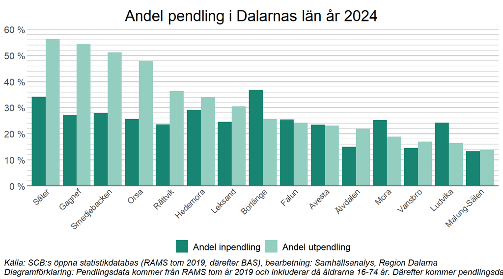

Figur 19.

## 2.5 Utbildningsnivå

Utbildningsnivån bland Dalarnas invånare varierar såväl mellan kvinnor och män, som mellan inrikes och utrikes födda. Kvinnor har generellt en högre utbildningsnivå än män. Av alla kvinnor 20-64 år i Dalarna har 43 procent (inrikes och utrikes födda) en eftergymnasial utbildning jämfört med 27 procent av männen. De utrikes födda kvinnorna har en något lägre andel eftergymnasialt utbildade än inrikes födda kvinnor men högre andel än de inrikes födda männen.

Den största skillnaden mellan inrikes och utrikes födda återfinns bland de med lägst utbildningsnivå. Knappt var tionde inrikes född 20-64 år har en förgymnasial utbildning, dvs. högst grundskoleutbildning (11 procent av männen och 7 procent av kvinnorna). För utrikes födda är det var fjärde som har högst en grundskoleutbildning och här är det inte någon skillnad mellan kvinnor och män. En hög andel lågutbildade är en viktig förklaring till att utrikes födda har en klart lägre sysselsättningsgrad än inrikes födda. Personer med lägre utbildningsnivå har svårare att möta företagens kompetenskrav och hitta jobb, och har därför generellt sett svårare att etablera sig på arbetsmarknaden.

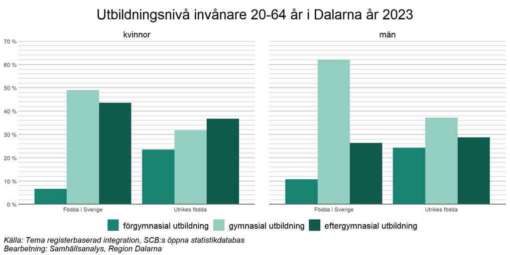

Figur 20.

Det är även stora skillnader i utbildningsnivå mellan åldersgrupper. Om vi enbart fokuserar på de med en lägst utbildning, är det tydligt att äldre är överrepresenterade i Dalarna. Detta beror sannolikt på att utbildningsnivån i samhället har ökat över tid. Längre tillbaka var kraven på arbetsmarknaden lägre, vilket gjorde det möjligt att gå ut högstadiet och sedan få ett jobb, något som är mycket svårare idag.

Antalet med låg utbildning minskar därefter med åldern ner till åldersgruppen runt 40 år, innan mönstret bryts. Att yngre åldersgrupper, framförallt de mellan 20 och 35 år, har relativt många med låg utbildning, beror troligtvis på att personer födda utrikes, som generellt har en lägre utbildningsnivå än inrikes födda, är överrepresenterade i dessa åldersgrupper.

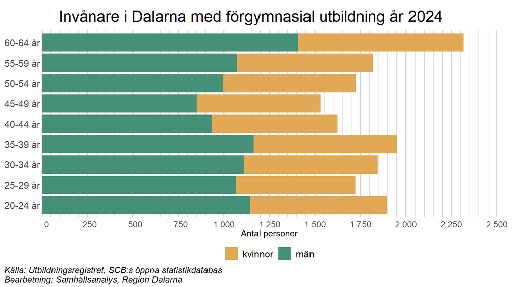

Figur 21.

I jämförelse med andra län är utbildningsnivån i Dalarna relativt låg, men också med en relativt stor spridning mellan kvinnor och män. År 2024 hade Dalarna tredje lägst andel med eftergymnasialt utbildade bland Sveriges län. Ungefär 31 procent av kvinnorna och 16 procent av männen i Dalarna har en eftergymnasial utbildning om minst 3 år. Det kan jämföras med 46 procent för kvinnor respektive 35 procent för män i Stockholm, det län som har högst utbildningsnivå i Sverige.

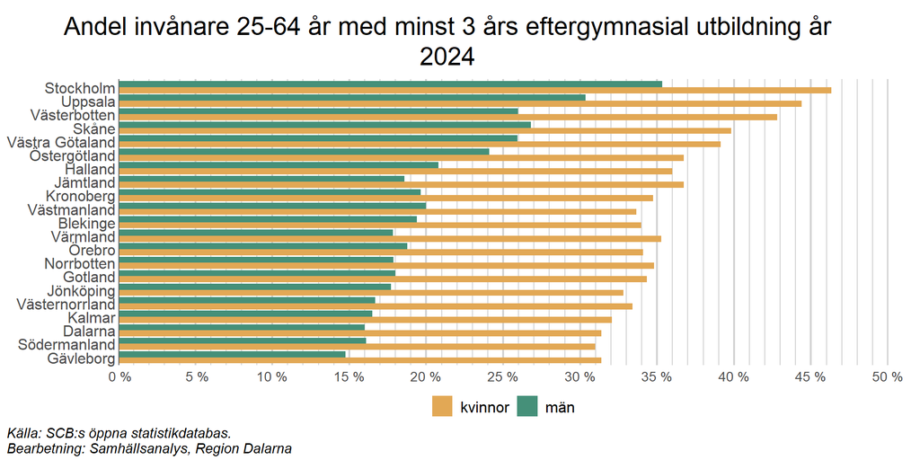

Figur 22.

Utbildningsnivån i samhället har dock ökat avsevärt över tid, vilket vi har berört tidigare. Andelen kvinnor som har minst tre års eftergymnasial utbildning i Dalarna har ökat från ungefär 7 procent till cirka 31 procent mellan 1985 och 2024. Andelen män med motsvarande utbildningsnivå har ökat från ungefär 7 procent till cirka 16 procent under samma tidsperiod.

Det finns flera möjliga förklaringar till att fler kvinnor än män är högt utbildade. En orsak är att kvinnor i högre utsträckning jobbar inom vård och omsorg samt utbildning, där de flesta yrkesgrupper kräver eftergymnasial utbildning på minst tre år. En annan förklaring är att kvinnor generellt sätt, oavsett utbildning, påbörjar eftergymnasiala studier i högre utsträckning än män ([SCB, 2019](https://www.scb.se/contentassets/0c78685c9da142eb921b46f0e2caf4d2/uf0549_2019a01_sm_a40br1903.pdf))

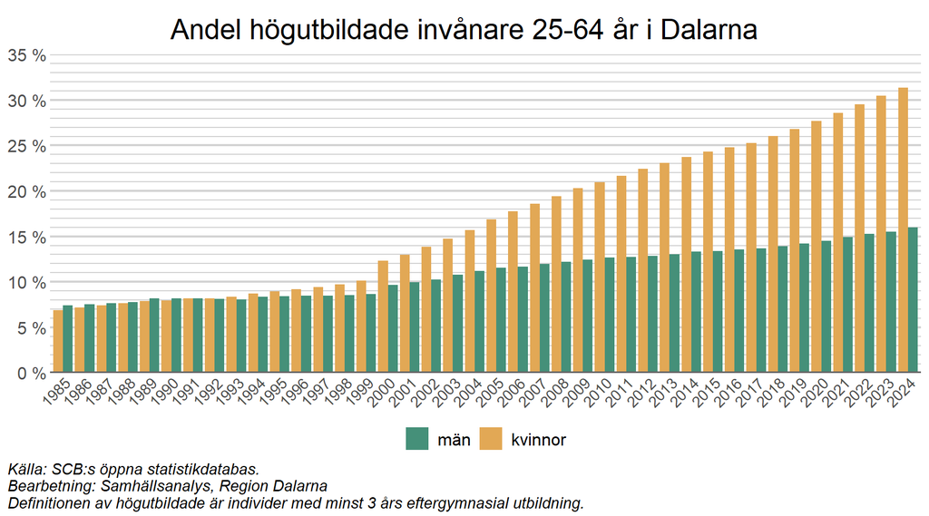

Figur 23.

# 3 Gymnasiet, högskolan och yrkeshögskolan

En viktig komponent för att matcha utbudet av arbetskraft med efterfrågan på arbetsmarknaden är att se till att utbildningssystemet är anpassat till arbetsmarknadens behov. Det är därför viktigt att studera mer ingående vilka typer av utbildningar som erbjuds och efterfrågas i Dalarna, på alla utbildningsnivåer.

För att få en bättre uppfattning om utbildningssystemet i Dalarna och hur det fungerar, rekommenderas att läsa:

**En kort introduktion till utbildningssystemet i Dalarna**

Utbildningssystemet är uppdelat i flera nivåer och sträcker sig från förskola till högre utbildning. Här är en översikt över de olika utbildningsnivåerna efter grundskolan:

Efter avslutad grundskola kan eleverna välja att fortsätta till **gymnasieskolan**, som varar i tre år. Gymnasieskolan ger eleverna möjlighet att specialisera sig inom olika ämnesområden och förbereder dem för högre utbildning eller arbetsmarknaden. Studieinriktningar kan vara allt ifrån högskoleförberedande program till yrkesinriktade program. Några av de mindre kommunerna i Dalarna har inte egen gymnasieutbildning, utan de samverkar med andra kommuner för att erbjuda gymnasieutbildning. I vissa kommuner som erbjuder gymnasieskola kan det finnas samarbeten för att erbjuda elever program som inte finns inom kommunens utbud.

Det finns påläggsutbildningar eller kompletterande utbildningar som erbjuds till vuxna som inte är på högskolenivå. Det övergripande namnet på dessa är **Vux**. I Dalarna så går Vux under namnet DalaWux, vilket är ett samverkansorgan för all den kommunala vuxenutbildningen i alla 15 kommuner i Dalarna. Komvux är ett annat namn för den kommunala vuxenutbildningen. Syftet med Komvux är att en elev får möjlighet att förse sig med grundskole- och gymnasieutbildning för dem som saknar dessa kvalifikationer. Inom Komvux kan en elev läsa allt ifrån enstaka kurser till hela utbildningspaket, vissa yrkesutbildningar sker på Komvuxnivå, precis som på gymnasienivå.

En annan utbildningsform för vuxna är **YH-utbildning**, vilket står för yrkeshögskoleutbildning. YH-utbildningar sker i samarbete med näringslivet och är meningen att de ska leda till jobb efter examen. Merparten av YH-utbildningen sker via kurser, men ungefär en tredjedel av utbildning sker via praktik, så kallat lärande i arbetslivet (LIA). De flesta YH-utbildningarna varar mellan 1-2 år och består av 200-40O YH-poäng, där fem poäng motsvarar en veckas studier.

**Folkhögskolor** är utbildningsinstitutioner som erbjuder vuxenutbildning på en informell och folklig nivå. Dessa skolor har sitt ursprung i 1800-talets folkbildningsrörelse och strävar efter att erbjuda möjligheter till personlig utveckling och lärande utan formella krav på förkunskaper eller examensbevis. Folkhögskolorna är öppna för alla, oavsett ålder eller tidigare utbildning. Eleverna uppmuntras att delta aktivt i gemenskapen och bidra till en öppen och inkluderande lärandemiljö. Då folkhögskolorna inte utmynnar i traditionella examina, är de friare att experimentera med innehållet och läroplanen. Till skillnad från annan vuxenutbildning så syftar deras kurser snarare till att berika individens personliga och kreativa erfarenheter.

Den sista varianten av utbildning är **arbetsmarknadsutbildning** som oftast sker inom ramen för Arbetsförmedlingens uppdrag. Syftet är att erbjuda en kort, yrkesinriktad utbildning som kan leda till jobb inom yrken där det är brist på utbildad personal och den är framförallt inriktad till personer som av olika skäl har svårt att hitta jobb. Oftast sker utbildningen genom att Arbetsförmedlingen beställer en riktad utbildning av en privat eller kommunal utbildningsanordnare, för att fylla kompetensluckor som finns på arbetsmarknaden.

## 3.1 Gymnasiet

Vid antagningen hösten 2025 antogs flest unga i Dalarna till introduktionsprogramet, ett program dit enbart personer som inte är behöriga till andra program antas. Bland de nationella programmen antogs flest till ekonomiprogrammet, samhällsvetenskapsprogrammet och teknikprogrammet. Högskoleförberedande program är således mest populära bland länets ungdomar. Bland yrkesförberedande program antogs flest till bygg- och anläggningsprogrammet respektive fordons- och transportprogrammet.

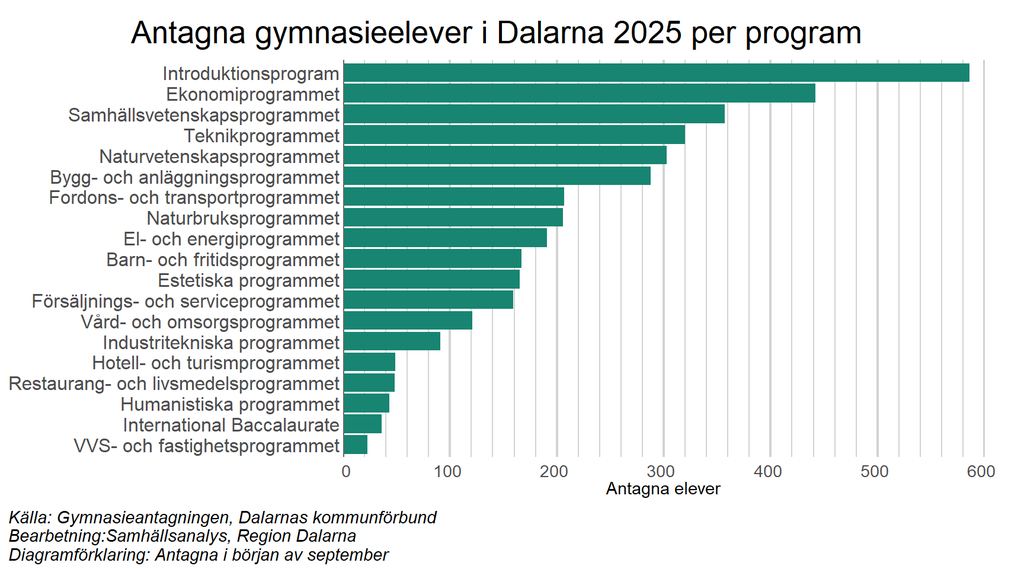

Figur 24.

Det råder stora könsmässiga skillnader mellan antagna till olika program. För högskoleförberedande program är obalansen störst på humanistiska programmet, dit klart flest flickor antas och teknikprogrammet, dit klart flest pojkar antas. Bland yrkesförberedande program är det en överväldigande majoritet flickor som antas till vård- och omsorgsprogrammet, medan en överväldigande majoritet pojkar antas till el- och energiprogrammet samt vvs- och fastighetsprogrammet. Dessa obalanser återspeglas även senare i arbetslivet. Kvinnor är överrepresenterade inom vård och omsorg, och utbildning, medan män är i klar majoritet inom byggsektorn. Om målsättningen är att skapa en mer jämställd fördelning mellan olika branscher i arbetslivet, är det således viktigt att börja arbetet redan i skolan. Det finns uppenbarligen stora skillnader mellan vilka val pojkar och flickor gör redan då.

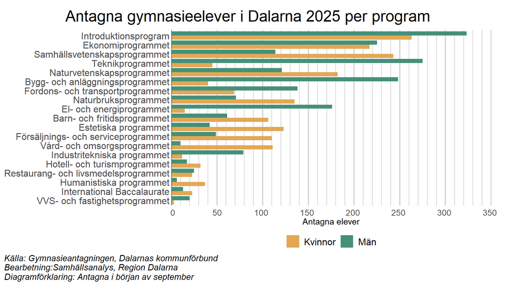

Figur 25.

Det program som ökat klart mest i antalet antagna är introduktionsprogrammet. År 2011 antogs 91 personer till programmet, en siffra som ökat till 586 personer år 2025. Bland studieförberedande program är ökningen störst på ekonomiprogrammet, dit mer än dubbelt så många antas idag som 2011. Bland program som i första hand kan ses som yrkesförberedande har antalet antagna till naturbruksprogrammet ökat avsevärt sedan 2011, medan antalet antagna till restaurang- och livsmedelsprogrammet har minskat tydligt.

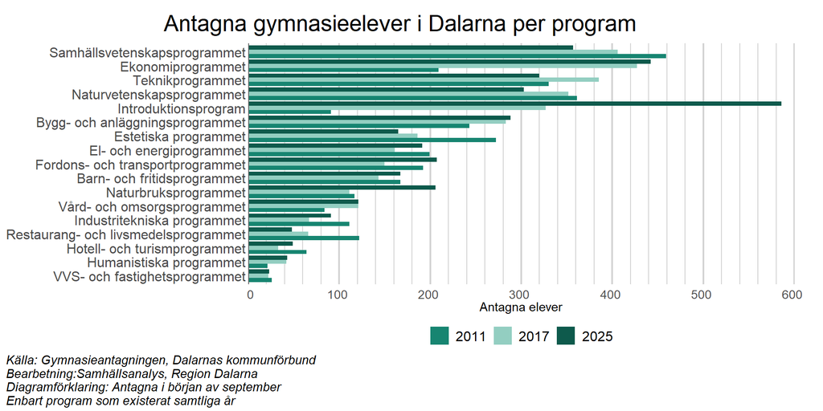

Figur 26.

Prognosen för den kommande tioårsperioden pekar inte på några dramatiska förändringar i nuvarande antagningsmönster. Introduktionsprogrammet förväntas även framöver vara det största programmet, följt av samhällsvetenskap, ekonomi och naturvetenskap.

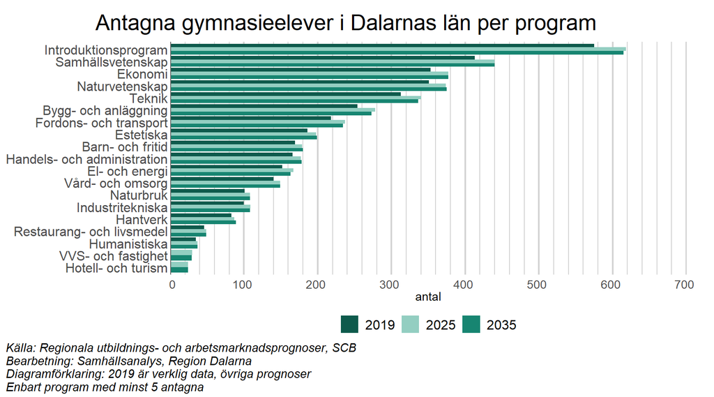

Figur 27.

## 3.2 Högskolan

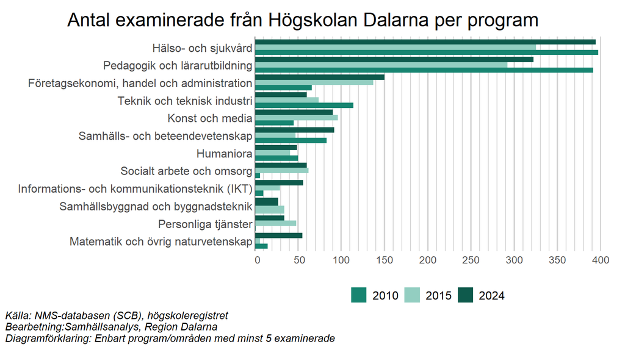

Figur 28.

## 3.3 Yrkeshögskolan

**Mer information om utbildningsformen**

En yrkeshögskola är en utbildningsform för yrkesinriktade studier på eftergymnasial nivå. Dess exakta roll varierar mellan olika länder. Inom yrkeshögskolan i Sverige finns två typer av examen på eftergymnasial nivå:

- yrkeshögskoleexamen, vilken motsvarar minst ett års studier på eftergymnasial nivå
- kvalificerad yrkeshögskoleexamen, vilken motsvarar studier under minst två år på denna nivå

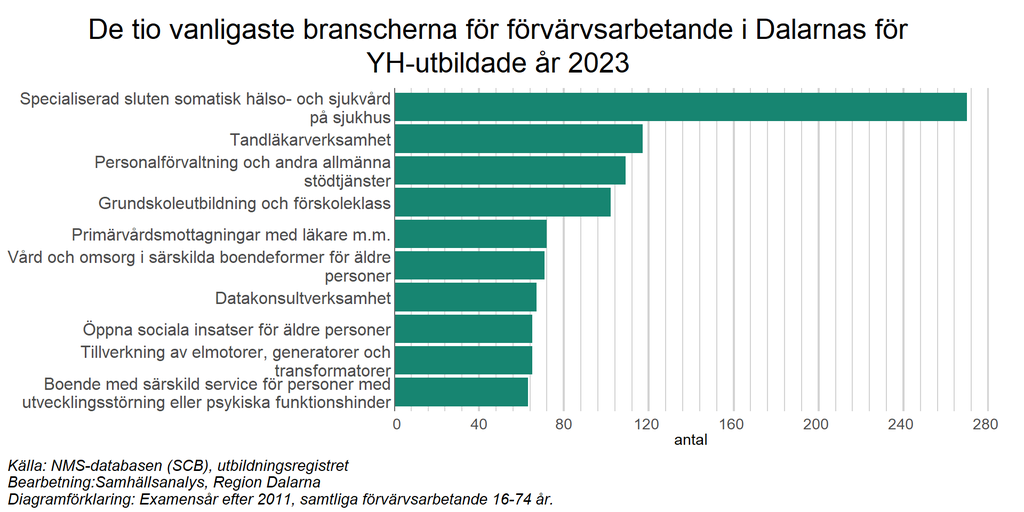

Figur 29.

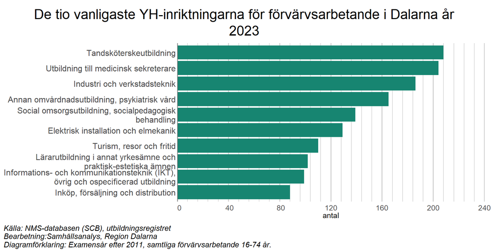

Figur 30.

2018 påbörjade drygt 190 personer en YH-utbildning i Dalarna. De efterföljande tre åren ökade antalet till cirka 250 för att därefter minska till knappt 160 personer under 2022-2024 (utbudet fastställs över en treårsperiod). Utbudet från 2025-2027 fastställs i nästa ansökningsperiod.

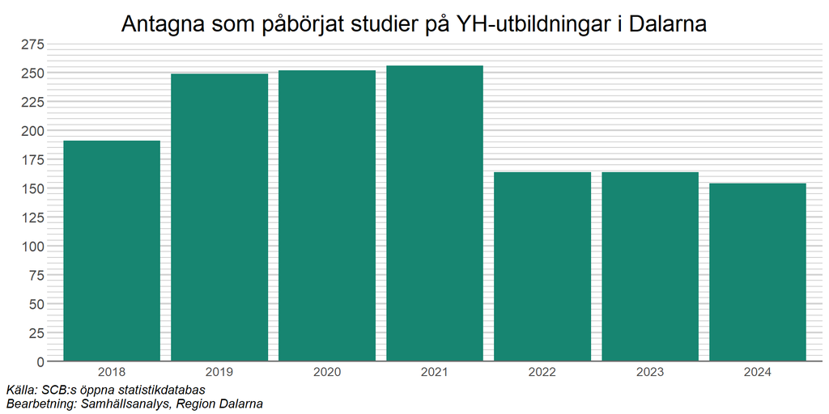

Figur 31.